# Μηνάς Ελευθερίου ΑΜ:4245 Data Mining - Lab1

```python
df1.style.background_gradient(cmap='Blues')
```

|  | count | mean | mean_stars |
| --- | --- | --- | --- |
| 19125.000000 | 614.000000 | 322289.761401 | 4.062319 |
| 19147.000000 | 613.000000 | 439699.007341 | 3.954861 |
| 19146.000000 | 596.000000 | 385841.464765 | 3.935345 |
| 19143.000000 | 587.000000 | 171869.457411 | 3.754658 |
| 19003.000000 | 586.000000 | 348269.932594 | 4.000000 |
| 19130.000000 | 575.000000 | 422198.866957 | 3.841615 |
| 19131.000000 | 575.000000 | 140046.690435 | 3.138889 |
| 19128.000000 | 572.000000 | 245242.848776 | 3.698333 |
| 19122.000000 | 568.000000 | 298092.669014 | 3.997093 |
| 19119.000000 | 558.000000 | 283418.258961 | 3.991379 |
| 19010.000000 | 556.000000 | 469248.786871 | 4.500000 |
| 19121.000000 | 556.000000 | 187552.202338 | 3.239130 |
| 19136.000000 | 555.000000 | 154764.408108 | 3.520833 |
| 19104.000000 | 554.000000 | 260677.601986 | 3.500849 |
| 19111.000000 | 552.000000 | 198419.894928 | 3.446043 |
| 19152.000000 | 546.000000 | 186306.828755 | 3.366071 |
| 19115.000000 | 545.000000 | 219089.412844 | 3.474522 |
| 19014.000000 | 544.000000 | 207546.861213 | 3.500000 |
| 19144.000000 | 539.000000 | 145965.595547 | 3.437500 |
| 19145.000000 | 532.000000 | 235429.111842 | 3.763538 |
| 19129.000000 | 526.000000 | 271857.388783 | 3.782178 |
| 19123.000000 | 520.000000 | 448157.588462 | 3.862385 |
| 19114.000000 | 520.000000 | 196791.453846 | 3.308511 |
| 19116.000000 | 515.000000 | 239971.022330 | 3.631206 |
| 19127.000000 | 512.000000 | 259437.509766 | 3.903433 |
| 19023.000000 | 508.000000 | 80747.046260 | 2.000000 |
| 19139.000000 | 503.000000 | 115134.535785 | 3.331325 |
| 19134.000000 | 501.000000 | 106830.331337 | 3.602500 |
| 19154.000000 | 498.000000 | 204091.667671 | 3.171296 |
| 19151.000000 | 494.000000 | 172939.001012 | 3.235294 |
| 19124.000000 | 487.000000 | 103389.964066 | 3.302326 |
| 19141.000000 | 485.000000 | 117442.759794 | 3.041667 |
| 19120.000000 | 482.000000 | 110799.467842 | 3.411765 |
| 19118.000000 | 478.000000 | 545145.694561 | 3.827381 |
| 19135.000000 | 476.000000 | 136225.412815 | 3.471774 |
| 19148.000000 | 473.000000 | 257632.368922 | 3.846918 |
| 19106.000000 | 462.000000 | 647241.991342 | 3.882445 |
| 19126.000000 | 458.000000 | 167562.029476 | 3.761905 |
| 19103.000000 | 450.000000 | 671583.041111 | 3.817833 |
| 19149.000000 | 447.000000 | 173474.359060 | 3.371212 |
| 19140.000000 | 444.000000 | 63528.413288 | 3.250000 |
| 19138.000000 | 443.000000 | 127413.851016 | 3.242424 |
| 19107.000000 | 434.000000 | 434303.716590 | 3.745580 |
| 19142.000000 | 421.000000 | 78101.157957 | 3.500000 |
| 19150.000000 | 409.000000 | 182379.303178 | 3.260417 |
| 19132.000000 | 408.000000 | 56832.725490 | 3.266667 |
| 19137.000000 | 395.000000 | 152534.313924 | 3.260417 |
| 19133.000000 | 362.000000 | 88870.348066 | 3.357143 |
| 19153.000000 | 358.000000 | 134829.691341 | 2.841727 |
| 19102.000000 | 345.000000 | 596292.791304 | 3.677677 |
| 19110.000000 | 252.000000 | 334245.817460 | 4.000000 |
| 19112.000000 | 6.000000 | 165000.000000 | 3.884615 |

```python
res = stats.pearsonr(df1['count'], df1['mean'])
res1 = stats.pearsonr(df1['count'], df1['mean_stars'])
res2 = stats.pearsonr(df1['mean'], df1['mean_stars'])
print(res)
print(res.confidence_interval())
print(res1)
print(res1.confidence_interval())
print(res2)
print(res2.confidence_interval())
```

```
PearsonRResult(statistic=0.09888274211137021, pvalue=0.48553241819094717)
ConfidenceInterval(low=-0.17884369731924885, high=0.36201406356107363)
PearsonRResult(statistic=0.09544757833839417, pvalue=0.5008900061212752)
ConfidenceInterval(low=-0.18219858991516955, high=0.3589968635542903)
PearsonRResult(statistic=0.6191395528598719, pvalue=9.935485916459114e-07)
ConfidenceInterval(low=0.4166353520183071, high=0.7631033493635309)
```

Δεν παρατηρούμε καμία ενδιαφέρον συσχέτιση εκτώς απο του mean(median_sale_price) και του mean_stars το οποίο έχει μικρό p-value και σχετικα το πιο μεγαλο coefficient

```python
df2 = df1[df1['mean'] > 200000]
```

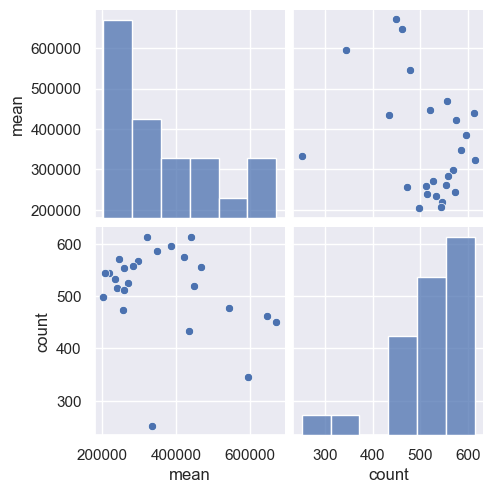

```python
sns.pairplot(df2[['mean','count']])
```

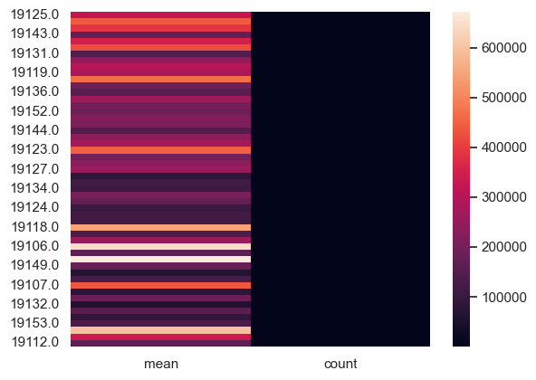

```python
sns.heatmap(df1[['mean','count']])
```

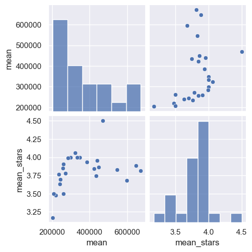

```python
sns.pairplot(df2[['mean','mean_stars']])
```

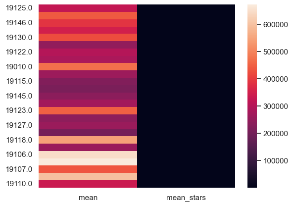

```python
sns.heatmap(df2[['mean','mean_stars']])
```

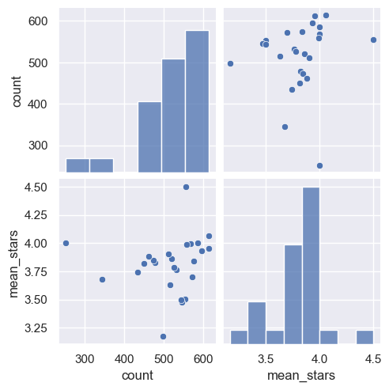

```python
sns.pairplot(df2[['count','mean_stars']])
```

```python
df2.style.background_gradient(cmap='Blues')
```

|  | count | mean | mean_stars |
| --- | --- | --- | --- |
| 19125.000000 | 614.000000 | 322289.761401 | 4.062319 |
| 19147.000000 | 613.000000 | 439699.007341 | 3.954861 |
| 19146.000000 | 596.000000 | 385841.464765 | 3.935345 |
| 19003.000000 | 586.000000 | 348269.932594 | 4.000000 |
| 19130.000000 | 575.000000 | 422198.866957 | 3.841615 |
| 19128.000000 | 572.000000 | 245242.848776 | 3.698333 |
| 19122.000000 | 568.000000 | 298092.669014 | 3.997093 |
| 19119.000000 | 558.000000 | 283418.258961 | 3.991379 |
| 19010.000000 | 556.000000 | 469248.786871 | 4.500000 |
| 19104.000000 | 554.000000 | 260677.601986 | 3.500849 |
| 19115.000000 | 545.000000 | 219089.412844 | 3.474522 |
| 19014.000000 | 544.000000 | 207546.861213 | 3.500000 |
| 19145.000000 | 532.000000 | 235429.111842 | 3.763538 |
| 19129.000000 | 526.000000 | 271857.388783 | 3.782178 |
| 19123.000000 | 520.000000 | 448157.588462 | 3.862385 |
| 19116.000000 | 515.000000 | 239971.022330 | 3.631206 |
| 19127.000000 | 512.000000 | 259437.509766 | 3.903433 |
| 19154.000000 | 498.000000 | 204091.667671 | 3.171296 |
| 19118.000000 | 478.000000 | 545145.694561 | 3.827381 |
| 19148.000000 | 473.000000 | 257632.368922 | 3.846918 |
| 19106.000000 | 462.000000 | 647241.991342 | 3.882445 |
| 19103.000000 | 450.000000 | 671583.041111 | 3.817833 |
| 19107.000000 | 434.000000 | 434303.716590 | 3.745580 |
| 19102.000000 | 345.000000 | 596292.791304 | 3.677677 |
| 19110.000000 | 252.000000 | 334245.817460 | 4.000000 |

```python
res = stats.pearsonr(df2['count'], df2['mean'])
res1 = stats.pearsonr(df2['count'], df2['mean_stars'])
res2 = stats.pearsonr(df2['mean'], df2['mean_stars'])
print(res)
print(res.confidence_interval())
print(res1)
print(res1.confidence_interval())
print(res2)
print(res2.confidence_interval())
```

```
PearsonRResult(statistic=-0.32364735203812967, pvalue=0.1145179040231449)
ConfidenceInterval(low=-0.6372808232520966, high=0.08196555323598553)
PearsonRResult(statistic=0.10896337530436188, pvalue=0.6041286853089258)
ConfidenceInterval(low=-0.2990427481013036, high=0.48328647334968106)
PearsonRResult(statistic=0.35550543407031127, pvalue=0.08115661813366842)
ConfidenceInterval(low=-0.046101380025231856, high=0.6581808860181211)
```

Δεν παρατηρούμε κατι ενδιαφέρον πλεον το δειγμά μας είναι αδιάφορο και απορριπτούμε την αρχική υπόθεση!

# Δ.

```python
ndf['categories'] = ndf['categories'].astype('str')
```

```python
ndf2 = pd.DataFrame()
```

```python
ndf = ndf[ndf['categories'].str.contains('Restaurants')]
```

```python
ndf.shape
```

```
(4830, 14)
```

```python
ndf.dtypes
```

```
business_id      object
name             object
address          object
city             object
state            object
postal_code     float64
latitude        float64
longitude       float64
stars           float64
review_count      int64
is_open           int64
attributes       object
categories       object
hours            object
dtype: object
```

```python
print(ndf["attributes"].iloc[1])
```

```
{'RestaurantsReservations': 'True', 'RestaurantsGoodForGroups': 'True', 'RestaurantsAttire': "'casual'", 'BusinessAcceptsCreditCards': 'True', 'WiFi': "'free'", 'HasTV': 'False', 'RestaurantsTakeOut': 'True', 'Ambience': "{'touristy': False, 'hipster': False, 'romantic': False, 'divey': False, 'inti…
```

```python
ndf['attributes'] = ndf['attributes'].apply(ast.literal_eval)
```

```python
ndf2 = ndf["attributes"].apply(pd.Series)
```

```python
value = ndf2.loc[0, ("RestaurantsPriceRange2")]
```

```python
ndf2.dtypes
```

```
RestaurantsDelivery           object
OutdoorSeating                object
BusinessAcceptsCreditCards    object
BusinessParking               object
BikeParking                   object
RestaurantsPriceRange2        object
RestaurantsTakeOut            object
ByAppointmentOnly             object
WiFi                          object
Alcohol                       object
Caters                        object
RestaurantsReservations       object
RestaurantsGoodForGroups      object
RestaurantsAttire             object
HasTV                         object
Ambience                      object
GoodForKids                   object
GoodForMeal                   object
NoiseLevel                    object
DogsAllowed                   object
HappyHour                     object
WheelchairAccessible          object
RestaurantsTableService       object
Smoking                       object
Music                         object
GoodForDancing                object
BusinessAcceptsBitcoin        object
Corkage                       object
BYOBCorkage                   object
BestNights                    object
CoatCheck                     object
BYOB                          object
DriveThru                     object
Open24Hours                   object
AcceptsInsurance              object
AgesAllowed                   object
DietaryRestrictions           object
RestaurantsCounterService     object
dtype: object
```

```python
ndf['attributes'] = ndf2['RestaurantsPriceRange2']
```

```python
ndf = ndf.dropna()
```

```python
ndf
```

|  | business_id | name | address | city | state | postal_code | latitude | longitude | stars | review_count | is_open | attributes | categories | hours |
| --- | --- | --- | --- | --- | --- | --- | --- | --- | --- | --- | --- | --- | --- | --- |
| 0 | MTSW4McQd7CbVtyjqoe9mw | St Honore Pastries | 935 Race St | Philadelphia | PA | 19107.0 | 39.955505 | -75.155564 | 4.0 | 80 | 1 | 1 | Restaurants, Food, Bubble Tea, Coffee & Tea, B... | {'Monday': '7:0-20:0', 'Tuesday': '7:0-20:0', ... |
| 1 | MUTTqe8uqyMdBl186RmNeA | Tuna Bar | 205 Race St | Philadelphia | PA | 19106.0 | 39.953949 | -75.143226 | 4.0 | 245 | 1 | 2 | Sushi Bars, Restaurants, Japanese | {'Tuesday': '13:30-22:0', 'Wednesday': '13:30-... |
| 2 | ROeacJQwBeh05Rqg7F6TCg | BAP | 1224 South St | Philadelphia | PA | 19147.0 | 39.943223 | -75.162568 | 4.5 | 205 | 1 | 1 | Korean, Restaurants | {'Monday': '11:30-20:30', 'Tuesday': '11:30-20... |
| 3 | QdN72BWoyFypdGJhhI5r7g | Bar One | 767 S 9th St | Philadelphia | PA | 19147.0 | 39.939825 | -75.157447 | 4.0 | 65 | 0 | 2 | Cocktail Bars, Bars, Italian, Nightlife, Resta... | {'Monday': '16:0-0:0', 'Tuesday': '16:0-0:0', ... |
| 4 | Mjboz24M9NlBeiOJKLEd_Q | DeSandro on Main | 4105 Main St | Philadelphia | PA | 19127.0 | 40.022466 | -75.218314 | 3.0 | 41 | 0 | 1 | Pizza, Restaurants, Salad, Soup | {'Tuesday': '17:0-21:30', 'Wednesday': '17:0-1... |
| ... | ... | ... | ... | ... | ... | ... | ... | ... | ... | ... | ... | ... | ... | ... |
| 11062 | auwFZzfhe2pvFw43OfsAfw | Stina Pizzeria | 1705 Snyder Ave | Philadelphia | PA | 19145.0 | 39.925205 | -75.174728 | 4.5 | 112 | 1 | 2 | Pizza, Restaurants, Mediterranean | {'Tuesday': '16:0-22:0', 'Wednesday': '16:0-22... |
| 11068 | gPr1io7ks0Eo3FDsnDTYfg | Tata Cafe | 7201 Germantown Ave | Philadelphia | PA | 19119.0 | 40.060414 | -75.191084 | 4.0 | 21 | 0 | 1 | Sandwiches, Restaurants, Italian | {'Monday': '7:0-17:0', 'Tuesday': '7:0-17:0', ... |
| 11069 | wVxXRFf10zTTAs11nr4xeA | PrimoHoagies | 6024 Ridge Ave | Philadelphia | PA | 19128.0 | 40.032483 | -75.214430 | 3.0 | 55 | 1 | 2 | Restaurants, Specialty Food, Food, Sandwiches,... | {'Monday': '10:0-21:0', 'Tuesday': '10:0-21:0'... |
| 11070 | 8n93L-ilMAsvwUatarykSg | Kitchen Gia | 3716 Spruce St | Philadelphia | PA | 19104.0 | 39.951018 | -75.198240 | 3.0 | 22 | 0 | 2 | Coffee & Tea, Food, Sandwiches, American (Trad... | {'Monday': '9:0-19:30', 'Tuesday': '9:0-19:30'... |
| 11074 | WnT9NIzQgLlILjPT0kEcsQ | Adelita Taqueria & Restaurant | 1108 S 9th St | Philadelphia | PA | 19147.0 | 39.935982 | -75.158665 | 4.5 | 35 | 1 | 2 | Restaurants, Mexican | {'Monday': '11:0-22:0', 'Tuesday': '11:0-22:0'... |

4108 rows × 14 columns

```python
def classify_restaurant(price_range):
    if price_range in [1, 2]:
        return 'cheap'
    elif price_range in [3, 4]:
        return 'expensive'
```

```python
null_values = ndf['attributes'].isnull()
ndf['attributes'][null_values] = 0
ndf['attributes'] = ndf['attributes'].replace('None', 0)
ndf['attributes'] = ndf['attributes'].astype('int')
ndf['classification'] = ndf['attributes'].apply(classify_restaurant)
```

```python
ndf.dtypes
```

```
business_id        object
name               object
address            object
city               object
state              object
postal_code       float64
latitude          float64
longitude         float64
stars             float64
review_count        int64
is_open             int64
attributes          int32
categories         object
hours              object
classification     object
dtype: object
```

```python
ndf.tail(20)
```

|  | business_id | name | address | city | state | postal_code | latitude | longitude | stars | review_count | is_open | attributes | categories | hours | classification |
| --- | --- | --- | --- | --- | --- | --- | --- | --- | --- | --- | --- | --- | --- | --- | --- |
| 11024 | ZGH8MzJa7Q7iIpmtzBAJAQ | Manayunk Brewery | 4120 Main St | Philadelphia | PA | 19127.0 | 40.022471 | -75.218800 | 3.5 | 692 | 1 | 2 | Sushi Bars, American (New), Bars, Pizza, Ameri... | {'Wednesday': '12:0-20:0', 'Thursday': '12:0-2... | cheap |
| 11026 | 0jPp69hbYMOzRYbhLEzCjQ | Ti Penso | 2108 S St | Philadelphia | PA | 19146.0 | 39.944966 | -75.177386 | 4.0 | 50 | 0 | 2 | Food, Restaurants, Breakfast & Brunch, Dessert... | {'Monday': '0:0-0:0', 'Thursday': '17:0-23:0',... | cheap |
| 11027 | P0LuuY4gbVRWhUQ1wa6BrA | Fishtown Brewpub | 1101 Frankford Ave | Philadelphia | PA | 19125.0 | 39.967725 | -75.134025 | 3.5 | 95 | 0 | 2 | Gastropubs, Food, Brewpubs, Breweries, Restaur... | {'Tuesday': '16:0-2:0', 'Wednesday': '16:0-2:0... | cheap |
| 11029 | C9UylQTOh7uwZo4a7QhLyg | Friday Saturday Sunday | 261 S 21st St | Philadelphia | PA | 19103.0 | 39.948937 | -75.175954 | 4.5 | 287 | 1 | 4 | American (New), Restaurants, Salad, Seafood | {'Monday': '0:0-0:0', 'Wednesday': '17:0-22:0'... | expensive |
| 11034 | q0tB0ch5cFQQBSp5nUXRCQ | Wawa | 10901 Bustleton Ave | Philadelphia | PA | 19116.0 | 40.111571 | -75.023489 | 3.5 | 12 | 1 | 1 | Food, Convenience Stores, Sandwiches, Restaura... | {'Monday': '0:0-0:0', 'Tuesday': '0:0-0:0', 'W... | cheap |
| 11036 | zm9aNqkHHtp1f-VT3ZlOZw | Cafe Renata | 4305 Locust St | Philadelphia | PA | 19104.0 | 39.954059 | -75.209587 | 3.5 | 80 | 0 | 2 | Restaurants, Cafes, Mediterranean, Breakfast &... | {'Monday': '7:30-18:0', 'Tuesday': '7:30-18:0'... | cheap |
| 11040 | eLi0bpsDoWQkBhJX1d46tg | Fergie's Pub | 1214 Sansom St | Philadelphia | PA | 19107.0 | 39.949596 | -75.161128 | 3.5 | 286 | 1 | 2 | Event Planning & Services, Bars, Pubs, Nightli... | {'Monday': '12:0-2:0', 'Tuesday': '12:0-2:0', ... | cheap |
| 11041 | NO1pbRWkefeULr1xmDASYg | The Mildred | 824 S 8th St | Philadelphia | PA | 19147.0 | 39.938877 | -75.156333 | 4.0 | 91 | 0 | 3 | American (New), British, French, Restaurants, ... | {'Tuesday': '17:30-22:30', 'Wednesday': '17:30... | expensive |
| 11044 | VWUmZrvqTPNzZD3p_IJj7A | Headhouse Crab & Oyster Co | 119 South St | Philadelphia | PA | 19147.0 | 39.941185 | -75.144843 | 4.0 | 58 | 0 | 2 | Seafood, Live/Raw Food, Restaurants, Gluten-Free | {'Tuesday': '16:0-22:0', 'Wednesday': '16:0-22... | cheap |
| 11046 | BAf7Wu2Xo8HioALaBLRIwA | 10 Arts Bistro | The Ritz-Carlton Philadelphia, Ten Avenue of t... | Philadelphia | PA | 19102.0 | 39.951050 | -75.164276 | 3.5 | 170 | 0 | 3 | Nightlife, Bars, American (New), Lounges, Rest... | {'Monday': '11:30-14:0', 'Tuesday': '17:30-22:... | expensive |
| 11048 | bKaBjDbtwQh_T-3ZpKJxRQ | Mr Sushi | 7324 Oxford Ave | Philadelphia | PA | 19111.0 | 40.062374 | -75.083677 | 4.0 | 184 | 1 | 2 | Food, Sushi Bars, Desserts, Soup, Steakhouses,... | {'Monday': '11:30-21:30', 'Tuesday': '11:30-21... | cheap |
| 11052 | bmJgvpuf2GBXd62ELK0Q2w | Luigi’s Pizza Fresca | 2401 Fairmount Ave | Philadelphia | PA | 19130.0 | 39.967551 | -75.177122 | 4.0 | 249 | 1 | 1 | Italian, Pizza, Restaurants, Hawaiian | {'Monday': '10:0-22:0', 'Tuesday': '10:0-22:0'... | cheap |
| 11053 | w9_EQB0SuAFYxPMcfY_P_g | Mugshots Coffeehouse | 1925 Fairmount Ave | Philadelphia | PA | 19130.0 | 39.967478 | -75.169569 | 4.0 | 203 | 0 | 1 | Restaurants, Music Venues, Arts & Entertainmen... | {'Monday': '6:30-18:0', 'Tuesday': '6:30-18:0'... | cheap |
| 11055 | TKPAyOWcexkpVHPCdYTNmQ | Spuntino Wood Fired Pizza | 701 N 2nd St | Philadelphia | PA | 19123.0 | 39.962006 | -75.140950 | 4.5 | 209 | 1 | 2 | Pizza, Restaurants | {'Tuesday': '12:0-21:0', 'Wednesday': '12:0-21... | cheap |
| 11058 | nHsVsOms41FRXcFQM9mGXw | Pamir Grill Kabob | 719 Sansom St | Philadelphia | PA | 19106.0 | 39.948880 | -75.153243 | 4.0 | 36 | 0 | 2 | Halal, Afghan, Restaurants | {'Monday': '11:0-21:0', 'Tuesday': '11:0-21:0'... | cheap |
| 11062 | auwFZzfhe2pvFw43OfsAfw | Stina Pizzeria | 1705 Snyder Ave | Philadelphia | PA | 19145.0 | 39.925205 | -75.174728 | 4.5 | 112 | 1 | 2 | Pizza, Restaurants, Mediterranean | {'Tuesday': '16:0-22:0', 'Wednesday': '16:0-22... | cheap |
| 11068 | gPr1io7ks0Eo3FDsnDTYfg | Tata Cafe | 7201 Germantown Ave | Philadelphia | PA | 19119.0 | 40.060414 | -75.191084 | 4.0 | 21 | 0 | 1 | Sandwiches, Restaurants, Italian | {'Monday': '7:0-17:0', 'Tuesday': '7:0-17:0', ... | cheap |
| 11069 | wVxXRFf10zTTAs11nr4xeA | PrimoHoagies | 6024 Ridge Ave | Philadelphia | PA | 19128.0 | 40.032483 | -75.214430 | 3.0 | 55 | 1 | 2 | Restaurants, Specialty Food, Food, Sandwiches,... | {'Monday': '10:0-21:0', 'Tuesday': '10:0-21:0'... | cheap |
| 11070 | 8n93L-ilMAsvwUatarykSg | Kitchen Gia | 3716 Spruce St | Philadelphia | PA | 19104.0 | 39.951018 | -75.198240 | 3.0 | 22 | 0 | 2 | Coffee & Tea, Food, Sandwiches, American (Trad... | {'Monday': '9:0-19:30', 'Tuesday': '9:0-19:30'... | cheap |
| 11074 | WnT9NIzQgLlILjPT0kEcsQ | Adelita Taqueria & Restaurant | 1108 S 9th St | Philadelphia | PA | 19147.0 | 39.935982 | -75.158665 | 4.5 | 35 | 1 | 2 | Restaurants, Mexican | {'Monday': '11:0-22:0', 'Tuesday': '11:0-22:0'... | cheap |

```python
cheap = ndf[ndf['classification'] == 'cheap']
expensive = ndf[ndf['classification'] == 'expensive']
```

```python
ndf.head(10)
```

|  | business_id | name | address | city | state | postal_code | latitude | longitude | stars | review_count | is_open | attributes | categories | hours | classification |
| --- | --- | --- | --- | --- | --- | --- | --- | --- | --- | --- | --- | --- | --- | --- | --- |
| 0 | MTSW4McQd7CbVtyjqoe9mw | St Honore Pastries | 935 Race St | Philadelphia | PA | 19107.0 | 39.955505 | -75.155564 | 4.0 | 80 | 1 | 1 | Restaurants, Food, Bubble Tea, Coffee & Tea, B... | {'Monday': '7:0-20:0', 'Tuesday': '7:0-20:0', ... | cheap |
| 1 | MUTTqe8uqyMdBl186RmNeA | Tuna Bar | 205 Race St | Philadelphia | PA | 19106.0 | 39.953949 | -75.143226 | 4.0 | 245 | 1 | 2 | Sushi Bars, Restaurants, Japanese | {'Tuesday': '13:30-22:0', 'Wednesday': '13:30-... | cheap |
| 2 | ROeacJQwBeh05Rqg7F6TCg | BAP | 1224 South St | Philadelphia | PA | 19147.0 | 39.943223 | -75.162568 | 4.5 | 205 | 1 | 1 | Korean, Restaurants | {'Monday': '11:30-20:30', 'Tuesday': '11:30-20... | cheap |
| 3 | QdN72BWoyFypdGJhhI5r7g | Bar One | 767 S 9th St | Philadelphia | PA | 19147.0 | 39.939825 | -75.157447 | 4.0 | 65 | 0 | 2 | Cocktail Bars, Bars, Italian, Nightlife, Resta... | {'Monday': '16:0-0:0', 'Tuesday': '16:0-0:0', ... | cheap |
| 4 | Mjboz24M9NlBeiOJKLEd_Q | DeSandro on Main | 4105 Main St | Philadelphia | PA | 19127.0 | 40.022466 | -75.218314 | 3.0 | 41 | 0 | 1 | Pizza, Restaurants, Salad, Soup | {'Tuesday': '17:0-21:30', 'Wednesday': '17:0-1... | cheap |
| 5 | aPNXGTDkf-4bjhyMBQxqpQ | Craft Hall | 901 N Delaware Ave | Philadelphia | PA | 19123.0 | 39.962582 | -75.135657 | 3.5 | 65 | 1 | 2 | Eatertainment, Arts & Entertainment, Brewpubs,... | {'Monday': '0:0-0:0', 'Wednesday': '16:0-22:0'... | cheap |
| 7 | ppFCk9aQkM338Rgwpl2F5A | Wawa | 3604 Chestnut St | Philadelphia | PA | 19104.0 | 39.954573 | -75.194894 | 3.0 | 56 | 1 | 1 | Restaurants, Automotive, Delis, Gas Stations, ... | {'Monday': '0:0-0:0', 'Tuesday': '0:0-0:0', 'W... | cheap |
| 10 | 3BJxm-HnvzdwD1zjmSbmyQ | Golden Chopstick Chinese Restaurant | 1800 Spring Garden St | Philadelphia | PA | 19130.0 | 39.963078 | -75.168027 | 3.0 | 137 | 1 | 1 | Restaurants, Chinese | {'Monday': '0:0-0:0', 'Tuesday': '11:0-22:30',... | cheap |
| 13 | WYYdQDjx-DsCanlP0DpImQ | J Sushi | 243 S 10th St | Philadelphia | PA | 19107.0 | 39.947033 | -75.157434 | 4.5 | 72 | 0 | 2 | Seafood, Restaurants, Sushi Bars, Japanese | {'Tuesday': '11:0-22:0', 'Wednesday': '11:0-22... | cheap |
| 16 | O1oZpbZNDMH_gz8DhsZCdA | Wendy's | 700 E. Hunting Park | Philadelphia | PA | 19124.0 | 40.012141 | -75.115015 | 1.5 | 15 | 1 | 1 | Burgers, Restaurants, Fast Food | {'Monday': '10:0-2:0', 'Tuesday': '10:0-2:0', ... | cheap |

```python
ndf['mean_cheap'] = cheap['stars'].agg('mean')
ndf['mean_exp'] = expensive['stars'].agg('mean')
```

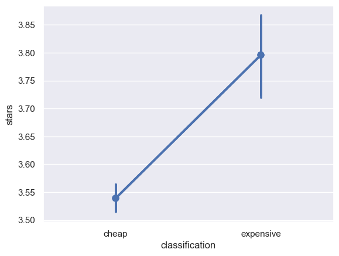

```python
sns.pointplot(x='classification', y='stars', data=ndf)

# Add 95% confidence intervals to the plot
sns.pointplot(x='classification', y='stars', data=ndf, ci=95)

# Show the plot
plt.show()
```

```python
import scipy.stats
# Conduct a t-test on the two groups of restaurants
result = scipy.stats.ttest_ind(ndf["mean_cheap"], ndf['mean_exp'])

# Interpret the results of the t-test
if result.pvalue < 0.05:
    print("The difference in average star ratings is statistically significant.")
    print(result)
else:
    print("The difference in average star ratings is not statistically significant.")
    print(result)
```

```
The difference in average star ratings is statistically significant.
Ttest_indResult(statistic=-1.0277561010976846e+16, pvalue=0.0)
```

# Τώρα θα ασχοληθούμε με το attribute RestaurantsAttire

```python
ndf = pd.read_csv('business.csv')
ndf2 = pd.DataFrame()
ndf = ndf[ndf['categories'].str.contains('Restaurants')]
ndf['attributes'] = ndf['attributes'].apply(ast.literal_eval)
ndf2 = ndf["attributes"].apply(pd.Series)
```

```python
ndf2.dtypes
```

```
RestaurantsDelivery           object
OutdoorSeating                object
BusinessAcceptsCreditCards    object
BusinessParking               object
BikeParking                   object
RestaurantsPriceRange2        object
RestaurantsTakeOut            object
ByAppointmentOnly             object
WiFi                          object
Alcohol                       object
Caters                        object
RestaurantsReservations       object
RestaurantsGoodForGroups      object
RestaurantsAttire             object
HasTV                         object
Ambience                      object
GoodForKids                   object
GoodForMeal                   object
NoiseLevel                    object
DogsAllowed                   object
HappyHour                     object
WheelchairAccessible          object
RestaurantsTableService       object
Smoking                       object
Music                         object
GoodForDancing                object
BusinessAcceptsBitcoin        object
Corkage                       object
BYOBCorkage                   object
BestNights                    object
CoatCheck                     object
BYOB                          object
DriveThru                     object
Open24Hours                   object
AcceptsInsurance              object
AgesAllowed                   object
DietaryRestrictions           object
RestaurantsCounterService     object
dtype: object
```

```python
ndf['attributes'] = ndf2['RestaurantsAttire']
```

```python
ndf['attributes'] = ndf['attributes'].dropna()
```

```python
print(ndf["attributes"].iloc[1])
```

```
'casual'
```

```python
ndf = ndf.dropna()
```

```python
ndf['attributes'].tail(20)
```

```
11014     'casual'
11020    u'casual'
11023     'casual'
11024    u'casual'
11026     'casual'
11029    u'dressy'
11036    u'casual'
11040     'casual'
11041    u'casual'
11044    u'casual'
11046     'dressy'
11048    u'casual'
11052    u'casual'
11053     'casual'
11055     'casual'
11058    u'casual'
11068     'casual'
11069    u'casual'
11070     'casual'
11074     'casual'
Name: attributes, dtype: object
```

```python
ndf['attributes'].dtypes
```

```
dtype('O')
```

```python
ndf['attributes'] = ndf['attributes'].astype('str')
```

```python
ndf['attributes'] = ndf['attributes'].apply(ast.literal_eval)
```

```python
ndf['attributes'].value_counts()
```

```
casual    3507
dressy      89
formal       5
Name: attributes, dtype: int64
```

```python
def get_type(value):
    if value == 'casual':
        return 'official'
    elif value == 'dressy':
        return 'unofficial'
    elif value == 'formal':
        return 'official'
```

```python
ndf['type'] = ndf['attributes'].apply(get_type)
```

```python
ndf['type'].value_counts()
```

```
official      3512
unofficial      89
Name: type, dtype: int64
```

```python
ndf['mean_cheap'] = cheap['stars'].agg('mean')
ndf['mean_exp'] = expensive['stars'].agg('mean')
```

```python
ndf.head(10)
```

|  | business_id | name | address | city | state | postal_code | latitude | longitude | stars | review_count | is_open | attributes | categories | hours | type | mean_cheap | mean_exp |
| --- | --- | --- | --- | --- | --- | --- | --- | --- | --- | --- | --- | --- | --- | --- | --- | --- | --- |
| 1 | MUTTqe8uqyMdBl186RmNeA | Tuna Bar | 205 Race St | Philadelphia | PA | 19106.0 | 39.953949 | -75.143226 | 4.0 | 245 | 1 | casual | Sushi Bars, Restaurants, Japanese | {'Tuesday': '13:30-22:0', 'Wednesday': '13:30-... | official | 3.539048 | 3.795833 |
| 2 | ROeacJQwBeh05Rqg7F6TCg | BAP | 1224 South St | Philadelphia | PA | 19147.0 | 39.943223 | -75.162568 | 4.5 | 205 | 1 | casual | Korean, Restaurants | {'Monday': '11:30-20:30', 'Tuesday': '11:30-20... | official | 3.539048 | 3.795833 |
| 3 | QdN72BWoyFypdGJhhI5r7g | Bar One | 767 S 9th St | Philadelphia | PA | 19147.0 | 39.939825 | -75.157447 | 4.0 | 65 | 0 | casual | Cocktail Bars, Bars, Italian, Nightlife, Resta... | {'Monday': '16:0-0:0', 'Tuesday': '16:0-0:0', ... | official | 3.539048 | 3.795833 |
| 4 | Mjboz24M9NlBeiOJKLEd_Q | DeSandro on Main | 4105 Main St | Philadelphia | PA | 19127.0 | 40.022466 | -75.218314 | 3.0 | 41 | 0 | casual | Pizza, Restaurants, Salad, Soup | {'Tuesday': '17:0-21:30', 'Wednesday': '17:0-1... | official | 3.539048 | 3.795833 |
| 7 | ppFCk9aQkM338Rgwpl2F5A | Wawa | 3604 Chestnut St | Philadelphia | PA | 19104.0 | 39.954573 | -75.194894 | 3.0 | 56 | 1 | casual | Restaurants, Automotive, Delis, Gas Stations, ... | {'Monday': '0:0-0:0', 'Tuesday': '0:0-0:0', 'W... | official | 3.539048 | 3.795833 |
| 10 | 3BJxm-HnvzdwD1zjmSbmyQ | Golden Chopstick Chinese Restaurant | 1800 Spring Garden St | Philadelphia | PA | 19130.0 | 39.963078 | -75.168027 | 3.0 | 137 | 1 | casual | Restaurants, Chinese | {'Monday': '0:0-0:0', 'Tuesday': '11:0-22:30',... | official | 3.539048 | 3.795833 |
| 13 | WYYdQDjx-DsCanlP0DpImQ | J Sushi | 243 S 10th St | Philadelphia | PA | 19107.0 | 39.947033 | -75.157434 | 4.5 | 72 | 0 | casual | Seafood, Restaurants, Sushi Bars, Japanese | {'Tuesday': '11:0-22:0', 'Wednesday': '11:0-22... | official | 3.539048 | 3.795833 |
| 16 | O1oZpbZNDMH_gz8DhsZCdA | Wendy's | 700 E. Hunting Park | Philadelphia | PA | 19124.0 | 40.012141 | -75.115015 | 1.5 | 15 | 1 | casual | Burgers, Restaurants, Fast Food | {'Monday': '10:0-2:0', 'Tuesday': '10:0-2:0', ... | official | 3.539048 | 3.795833 |
| 19 | bTve2mwLk5Zc01vRKqc2KQ | Red Hook Coffee & Tea | 765 S 4th St | Philadelphia | PA | 19147.0 | 39.938552 | -75.149636 | 4.5 | 183 | 1 | casual | Restaurants, Breakfast & Brunch, Vegan, Bagels... | {'Monday': '7:0-18:0', 'Tuesday': '7:0-18:0', ... | official | 3.539048 | 3.795833 |
| 24 | _T0cPZE2ZJOTTlYYKMP64Q | Brown Sugar Bakery & Cafe | 219 S 52nd St | Philadelphia | PA | 19139.0 | 39.956396 | -75.225378 | 4.5 | 66 | 1 | casual | Cupcakes, Caribbean, Restaurants, Trinidadian,... | {'Monday': '9:0-22:0', 'Tuesday': '9:0-22:0', ... | official | 3.539048 | 3.795833 |

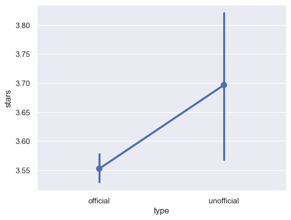

```python
sns.pointplot(x='type', y='stars', data=ndf)

# Add 95% confidence intervals to the plot
sns.pointplot(x='type', y='stars', data=ndf, ci=95)

# Show the plot
plt.show()
```

```python
import scipy.stats
# Conduct a t-test on the two groups of restaurants
result = scipy.stats.ttest_ind(ndf["mean_cheap"], ndf['mean_exp'])

# Interpret the results of the t-test
if result.pvalue < 0.05:
    print("The difference in average star ratings is statistically significant.")
    print(result)
else:
    print("The difference in average star ratings is not statistically significant.")
    print(result)
```

```
The difference in average star ratings is statistically significant.
Ttest_indResult(statistic=-1.156456719675092e+16, pvalue=0.0)
```

# E.

```python
ndf = pd.read_csv('business.csv')
ndf2 = pd.DataFrame()
ndf = ndf[ndf['categories'].str.contains('Restaurants')]
ndf['attributes'] = ndf['attributes'].apply(ast.literal_eval)
ndf2 = ndf["attributes"].apply(pd.Series)
```

```python
ndf2.dtypes
```

```
RestaurantsDelivery           object
OutdoorSeating                object
BusinessAcceptsCreditCards    object
BusinessParking               object
BikeParking                   object
RestaurantsPriceRange2        object
RestaurantsTakeOut            object
ByAppointmentOnly             object
WiFi                          object
Alcohol                       object
Caters                        object
RestaurantsReservations       object
RestaurantsGoodForGroups      object
RestaurantsAttire             object
HasTV                         object
Ambience                      object
GoodForKids                   object
GoodForMeal                   object
NoiseLevel                    object
DogsAllowed                   object
HappyHour                     object
WheelchairAccessible          object
RestaurantsTableService       object
Smoking                       object
Music                         object
GoodForDancing                object
BusinessAcceptsBitcoin        object
Corkage                       object
BYOBCorkage                   object
BestNights                    object
CoatCheck                     object
BYOB                          object
DriveThru                     object
Open24Hours                   object
AcceptsInsurance              object
AgesAllowed                   object
DietaryRestrictions           object
RestaurantsCounterService     object
dtype: object
```

```python
ndf['attributes'] = ndf2['Ambience']
```

```python
ndf['attributes'].value_counts()
```

```
{'touristy': False, 'hipster': False, 'romantic': False, 'divey': False, 'intimate': False, 'trendy': False, 'upscale': False, 'classy': False, 'casual': False}           577
{'romantic': False, 'intimate': False, 'touristy': False, 'hipster': False, 'divey': False, 'classy': False, 'trendy': False, 'upscale': False, 'casual': True}            487
{'romantic': False, 'intimate': False, 'classy': False, 'hipster': False, 'divey': False, 'touristy': False, 'trendy': False, 'upscale': False, 'casual': False}           347
{'romantic': False, 'intimate': False, 'classy': False, 'hipster': False, 'divey': False, 'touristy': False, 'trendy': False, 'upscale': False, 'casual': True}            313
{'romantic': False, 'intimate': False, 'touristy': False, 'hipster': False, 'divey': False, 'classy': False, 'trendy': False, 'upscale': False, 'casual': False}           250
                                                                                                                                                                          ...
{u'divey': False, u'hipster': False, u'casual': True, u'touristy': False, u'trendy': False, u'intimate': False, u'romantic': False, u'classy': False, u'upscale': None}      1
{'touristy': None, 'hipster': False, 'romantic': None, 'divey': None, 'intimate': None, 'trendy': None, 'upscale': False, 'classy': True, 'casual': True}                    1
{'touristy': False, 'hipster': False, 'romantic': None, 'divey': True, 'intimate': False, 'trendy': False, 'upscale': False, 'classy': False, 'casual': None}                1
{u'divey': None, u'hipster': None, u'casual': None, u'touristy': False, u'trendy': None, u'intimate': None, u'romantic': False, u'classy': None, u'upscale': False}          1
{u'divey': False, u'hipster': None, u'casual': True, u'touristy': None, u'trendy': True, u'intimate': None, u'romantic': None, u'classy': None, u'upscale': False}           1
Name: attributes, Length: 523, dtype: int64
```

```python
ndf = ndf.dropna()
```

```python
ndf['attributes'] = ndf['attributes'].apply(ast.literal_eval)
```

```python
#ndf3 = ndf["attributes"].apply(pd.Series).astype(bool)
```

```python
ndf3 = ndf3.astype(bool)
```

```python
ndf3.dtypes
```

```
touristy       bool
hipster        bool
romantic       bool
divey          bool
intimate       bool
trendy         bool
upscale        bool
classy         bool
casual         bool
dateability    bool
gentlemanly    bool
dtype: object
```

```python
ndf.shape
```

```
(3925, 14)
```

```python
ndf3.head(10)
```

|  | touristy | hipster | romantic | divey | intimate | trendy | upscale | classy | casual | dateability | gentlemanly |
| --- | --- | --- | --- | --- | --- | --- | --- | --- | --- | --- | --- |
| 1 | False | False | False | False | False | False | False | True | False | True | True |
| 2 | False | False | False | False | False | False | False | False | True | True | True |
| 3 | False | True | False | False | False | False | False | False | True | True | True |
| 4 | False | False | False | False | False | False | False | False | False | True | True |
| 5 | False | False | False | False | False | False | False | True | False | True | True |
| 7 | False | False | False | False | False | False | False | False | True | True | True |
| 10 | False | False | False | False | False | False | False | False | False | True | True |
| 13 | False | False | False | False | False | False | False | False | False | True | True |
| 19 | False | False | False | False | False | False | False | False | True | True | True |
| 24 | False | False | False | False | False | False | False | False | False | True | True |

```python
ndf['dateability'] = ndf3.apply(lambda x: 'good for dating' if (x['romantic'] or x['intimate']) else 'not good for dating', axis=1)

ndf['gentlemanly'] = ndf3.apply(lambda x: 'gentle' if (x['classy'] or x['upscale']) else 'not gentle', axis=1)
```

```python
ndf.head(10)
```

|  | business_id | name | address | city | state | postal_code | latitude | longitude | stars | review_count | is_open | attributes | categories | hours | dateability | gentlemanly |
| --- | --- | --- | --- | --- | --- | --- | --- | --- | --- | --- | --- | --- | --- | --- | --- | --- |
| 1 | MUTTqe8uqyMdBl186RmNeA | Tuna Bar | 205 Race St | Philadelphia | PA | 19106.0 | 39.953949 | -75.143226 | 4.0 | 245 | 1 | {'touristy': False, 'hipster': False, 'romanti... | Sushi Bars, Restaurants, Japanese | {'Tuesday': '13:30-22:0', 'Wednesday': '13:30-... | not good for dating | gentle |
| 2 | ROeacJQwBeh05Rqg7F6TCg | BAP | 1224 South St | Philadelphia | PA | 19147.0 | 39.943223 | -75.162568 | 4.5 | 205 | 1 | {'touristy': False, 'hipster': False, 'romanti... | Korean, Restaurants | {'Monday': '11:30-20:30', 'Tuesday': '11:30-20... | not good for dating | not gentle |
| 3 | QdN72BWoyFypdGJhhI5r7g | Bar One | 767 S 9th St | Philadelphia | PA | 19147.0 | 39.939825 | -75.157447 | 4.0 | 65 | 0 | {'touristy': False, 'hipster': True, 'romantic... | Cocktail Bars, Bars, Italian, Nightlife, Resta... | {'Monday': '16:0-0:0', 'Tuesday': '16:0-0:0', ... | not good for dating | not gentle |
| 4 | Mjboz24M9NlBeiOJKLEd_Q | DeSandro on Main | 4105 Main St | Philadelphia | PA | 19127.0 | 40.022466 | -75.218314 | 3.0 | 41 | 0 | {'romantic': False, 'intimate': False, 'classy... | Pizza, Restaurants, Salad, Soup | {'Tuesday': '17:0-21:30', 'Wednesday': '17:0-1... | not good for dating | not gentle |
| 5 | aPNXGTDkf-4bjhyMBQxqpQ | Craft Hall | 901 N Delaware Ave | Philadelphia | PA | 19123.0 | 39.962582 | -75.135657 | 3.5 | 65 | 1 | {'touristy': False, 'hipster': False, 'romanti... | Eatertainment, Arts & Entertainment, Brewpubs,... | {'Monday': '0:0-0:0', 'Wednesday': '16:0-22:0'... | not good for dating | gentle |
| 7 | ppFCk9aQkM338Rgwpl2F5A | Wawa | 3604 Chestnut St | Philadelphia | PA | 19104.0 | 39.954573 | -75.194894 | 3.0 | 56 | 1 | {'romantic': False, 'intimate': False, 'classy... | Restaurants, Automotive, Delis, Gas Stations, ... | {'Monday': '0:0-0:0', 'Tuesday': '0:0-0:0', 'W... | not good for dating | not gentle |
| 10 | 3BJxm-HnvzdwD1zjmSbmyQ | Golden Chopstick Chinese Restaurant | 1800 Spring Garden St | Philadelphia | PA | 19130.0 | 39.963078 | -75.168027 | 3.0 | 137 | 1 | {'touristy': False, 'hipster': False, 'romanti... | Restaurants, Chinese | {'Monday': '0:0-0:0', 'Tuesday': '11:0-22:30',... | not good for dating | not gentle |
| 13 | WYYdQDjx-DsCanlP0DpImQ | J Sushi | 243 S 10th St | Philadelphia | PA | 19107.0 | 39.947033 | -75.157434 | 4.5 | 72 | 0 | {'touristy': False, 'hipster': False, 'romanti... | Seafood, Restaurants, Sushi Bars, Japanese | {'Tuesday': '11:0-22:0', 'Wednesday': '11:0-22... | not good for dating | not gentle |
| 19 | bTve2mwLk5Zc01vRKqc2KQ | Red Hook Coffee & Tea | 765 S 4th St | Philadelphia | PA | 19147.0 | 39.938552 | -75.149636 | 4.5 | 183 | 1 | {'romantic': False, 'intimate': False, 'classy... | Restaurants, Breakfast & Brunch, Vegan, Bagels... | {'Monday': '7:0-18:0', 'Tuesday': '7:0-18:0', ... | not good for dating | not gentle |
| 24 | _T0cPZE2ZJOTTlYYKMP64Q | Brown Sugar Bakery & Cafe | 219 S 52nd St | Philadelphia | PA | 19139.0 | 39.956396 | -75.225378 | 4.5 | 66 | 1 | {'romantic': False, 'intimate': False, 'classy... | Cupcakes, Caribbean, Restaurants, Trinidadian,... | {'Monday': '9:0-22:0', 'Tuesday': '9:0-22:0', ... | not good for dating | not gentle |

```python
import pandas as pd

# Create the contingency table
table = pd.crosstab(ndf["dateability"], ndf["gentlemanly"])

# Print the contingency table
print(table)
```

```
gentlemanly          gentle  not gentle
dateability
good for dating         138          98
not good for dating     691        2998
```

```python
from scipy.stats import chi2_contingency
# Convert the table to a numpy array
table_array = table.to_numpy()

# Calculate the chi-squared statistic and p-value
chi2_stat, p_val, dof, ex = chi2_contingency(table_array)

# Print the p-value
print(p_val)
```

```
3.911140583534825e-47
```

# Σε αυτήν την περίπτωση, η τιμή p του 3,911140583534825e-47 είναι πολύ κάτω από το συνηθισμένο όριο του 0,05, γεγονός που δείχνει ότι υπάρχει στατιστικά σημαντική σχέση μεταξύ των δύο μεταβλητών. Αυτό σημαίνει ότι είναι απίθανο η παρατηρούμενη σχέση μεταξύ των χαρακτηριστικών «dateability» και «gentlemanly» ενός εστιατορίου να προέκυψε τυχαία και ότι πιθανότατα υπάρχει πραγματική σχέση μεταξύ αυτών των δύο χαρακτηριστικών.

# Z.

```python
ndf = pd.read_csv('business.csv')
```

```python
ndf
```

|  | business_id | name | address | city | state | postal_code | latitude | longitude | stars | review_count | is_open | attributes | categories | hours |
| --- | --- | --- | --- | --- | --- | --- | --- | --- | --- | --- | --- | --- | --- | --- |
| 0 | MTSW4McQd7CbVtyjqoe9mw | St Honore Pastries | 935 Race St | Philadelphia | PA | 19107.0 | 39.955505 | -75.155564 | 4.0 | 80 | 1 | {'RestaurantsDelivery': 'False', 'OutdoorSeati... | Restaurants, Food, Bubble Tea, Coffee & Tea, B... | {'Monday': '7:0-20:0', 'Tuesday': '7:0-20:0', ... |
| 1 | MUTTqe8uqyMdBl186RmNeA | Tuna Bar | 205 Race St | Philadelphia | PA | 19106.0 | 39.953949 | -75.143226 | 4.0 | 245 | 1 | {'RestaurantsReservations': 'True', 'Restauran... | Sushi Bars, Restaurants, Japanese | {'Tuesday': '13:30-22:0', 'Wednesday': '13:30-... |
| 2 | ROeacJQwBeh05Rqg7F6TCg | BAP | 1224 South St | Philadelphia | PA | 19147.0 | 39.943223 | -75.162568 | 4.5 | 205 | 1 | {'NoiseLevel': "u'quiet'", 'GoodForMeal': "{'d... | Korean, Restaurants | {'Monday': '11:30-20:30', 'Tuesday': '11:30-20... |
| 3 | QdN72BWoyFypdGJhhI5r7g | Bar One | 767 S 9th St | Philadelphia | PA | 19147.0 | 39.939825 | -75.157447 | 4.0 | 65 | 0 | {'Smoking': "u'no'", 'NoiseLevel': "u'average'... | Cocktail Bars, Bars, Italian, Nightlife, Resta... | {'Monday': '16:0-0:0', 'Tuesday': '16:0-0:0', ... |
| 4 | Mjboz24M9NlBeiOJKLEd_Q | DeSandro on Main | 4105 Main St | Philadelphia | PA | 19127.0 | 40.022466 | -75.218314 | 3.0 | 41 | 0 | {'RestaurantsReservations': 'False', 'Caters':... | Pizza, Restaurants, Salad, Soup | {'Tuesday': '17:0-21:30', 'Wednesday': '17:0-1... |
| ... | ... | ... | ... | ... | ... | ... | ... | ... | ... | ... | ... | ... | ... | ... |
| 11070 | 8n93L-ilMAsvwUatarykSg | Kitchen Gia | 3716 Spruce St | Philadelphia | PA | 19104.0 | 39.951018 | -75.198240 | 3.0 | 22 | 0 | {'RestaurantsGoodForGroups': 'True', 'BikePark... | Coffee & Tea, Food, Sandwiches, American (Trad... | {'Monday': '9:0-19:30', 'Tuesday': '9:0-19:30'... |
| 11071 | wPAaAbFbq5wfLfW0gnYU7g | Intermix | 1718 Walnut St | Philadelphia | PA | 19103.0 | 39.950060 | -75.170129 | 2.0 | 10 | 0 | {'BusinessParking': "{'garage': False, 'street... | Fashion, Shopping, Women's Clothing | {'Monday': '10:0-19:0', 'Tuesday': '10:0-19:0'... |
| 11072 | 9U1Igcpe954LoWZRmNc-zg | Hand & Stone Massage And Facial Spa | 1100 S Columbus Blvd, Ste 24 | Philadelphia | PA | 19147.0 | 39.932756 | -75.144504 | 3.0 | 32 | 1 | {'BusinessAcceptsCreditCards': 'True', 'Wheelc... | Day Spas, Beauty & Spas, Skin Care, Massage | {'Monday': '9:0-22:0', 'Tuesday': '9:0-22:0', ... |
| 11073 | LJ4GjQ1HL6kqvIPpNUNNaQ | Shanti Yoga and Ayurveda | 1638 Pine St, Fl 1 | Philadelphia | PA | 19103.0 | 39.945966 | -75.169666 | 4.5 | 39 | 1 | {'ByAppointmentOnly': 'True', 'GoodForKids': '... | Health & Medical, Yoga, Shopping, Naturopathic... | {'Monday': '7:0-20:0', 'Tuesday': '7:0-20:0', ... |
| 11074 | WnT9NIzQgLlILjPT0kEcsQ | Adelita Taqueria & Restaurant | 1108 S 9th St | Philadelphia | PA | 19147.0 | 39.935982 | -75.158665 | 4.5 | 35 | 1 | {'WheelchairAccessible': 'False', 'Restaurants... | Restaurants, Mexican | {'Monday': '11:0-22:0', 'Tuesday': '11:0-22:0'... |

11075 rows × 14 columns

```python
ndf['postal_code'].value_counts()
```

```
19103.0    1043
19107.0    1018
19147.0    1008
19106.0     638
19104.0     589
           ...
19004.0       1
19108.0       1
19100.0       1
19096.0       1
19020.0       1
Name: postal_code, Length: 82, dtype: int64
```

```python
ndf['categories'] = ndf['categories'].astype('str')
# Filter the DataFrame to exclude categories that contain "Restaurants"
ndf = ndf[~ndf['categories'].str.contains('Restaurants')]
```

```python
ndf.shape
```

```
(6245, 14)
```

```python
ndf.dtypes
```

```
business_id      object
name             object
address          object
city             object
state            object
postal_code     float64
latitude        float64
longitude       float64
stars           float64
review_count      int64
is_open           int64
attributes       object
categories       object
hours            object
dtype: object
```

```python
# Group the businesses by postal code
business_groups = ndf.groupby("postal_code")

# Count the number of businesses in each category for each group
category_counts = business_groups["categories"]
df = pd.DataFrame(category_counts)
```

```python
category_counts
```

```
<pandas.core.groupby.generic.SeriesGroupBy object at 0x000001CD870E6A60>
```

```python
df
```

|  | 0 | 1 |
| --- | --- | --- |
| 0 | 19003.0 | 3787 Contractors, Local Services, Home Serv... |
| 1 | 19004.0 | 422 Food Trucks, Food, Cupcakes, Street Ven... |
| 2 | 19006.0 | 8946 Home Services, Pest Control, Home Insp... |
| 3 | 19010.0 | 9090 Window Washing, Home Cleaning, Home Se... |
| 4 | 19012.0 | 7941 Massage Therapy, Health & Medical, Fit... |
| ... | ... | ... |
| 75 | 19406.0 | 1817 Local Services, IT Services & Computer... |
| 76 | 19428.0 | 2000 Local Services, Home Services, Movers,... |
| 77 | 19446.0 | 2131 Flooring, Tiling, Home & Garden, Kitch... |
| 78 | 43215.0 | 4910 Local Flavor, Party & Event Planning, ... |
| 79 | 55101.0 | 8966 Wedding Planning, Photographers, DJs, ... |

80 rows × 2 columns